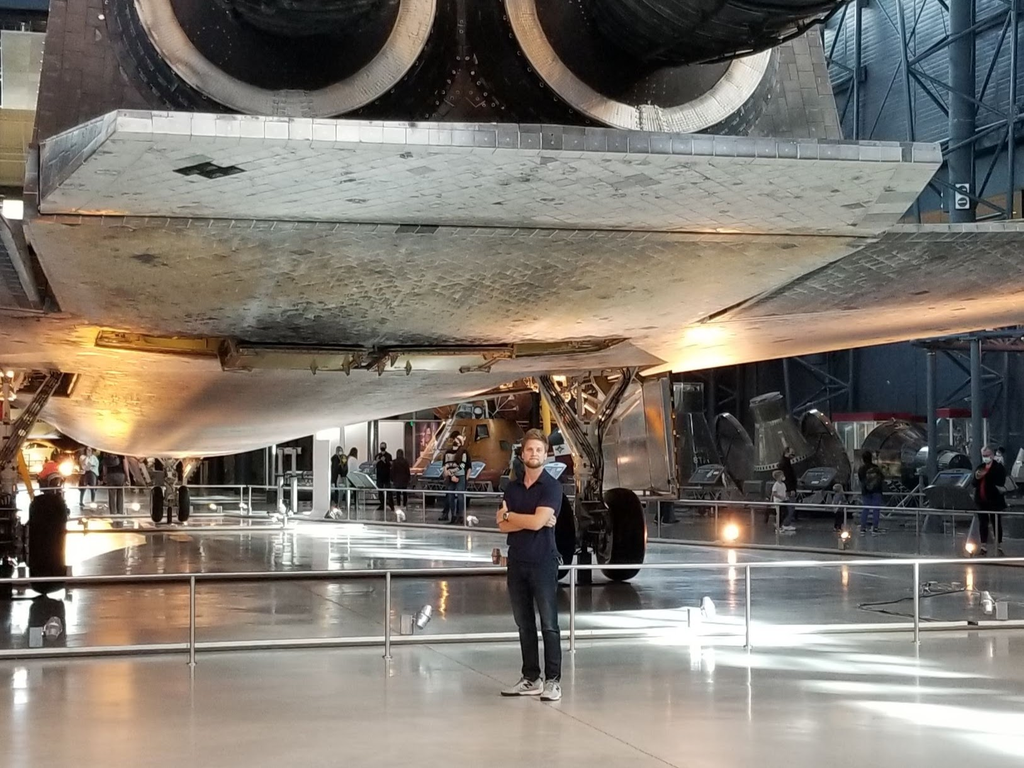

# The Dan Smyczek Fund

## Honoring his memory

Daniel J. Smyczek, University School of Milwaukee class of 2010, passed away tragically in August, 2022, at the age of 30. Dan was an avid teacher, a loyal friend, and a curious explorer. In particular, Dan was passionate about technologies that expand our frontiers and push the boundaries on what is humanly possible. After college, for example, Dan took the initiative to learn as much as he could about biotechnology, ultimately becoming an indispensable project manager helping to develop novel gene-delivery technologies. Still curious and eager to share his knowledge with others, Dan would start off each of his meetings with an update on development of the James Webb telescope. Had he lived, Dan would have undoubtedly continued to promote scientific research and educate his colleagues, friends, and many loving nieces and nephews.

## Helping the next generation

Dan was a dedicated man who understood that a strong foundation is needed to achieve great things. Whether it be on the hockey rink or in front of clients in the conference room, Dan’s successes could be traced back to his religious approach to preparation. In this spirit, Dan’s friends and family are organizing a fund for scientific education at USM. The fund will support extracurricular programs submitted by faculty at USM covering new, critically relevant developments in science and technology. Programs selected will provide interested students with exposure to university- or industry-level laboratories and resources, and foster novel student projects, with the goal to prepare these students to become leaders in the competitive and ever-changing fields of scientific research and technology development.